# Señales y Sistemas, Laboratorio 2

Karen del Rey y Álvaro López

3 de noviembre de 2020

# Práctica II: An´alisis de sistemas en el dominio temporal

En esta práctica se analizar´an los sistemas discretos. En un Anexo, que no forma parte de la práctica se verán los sistemas continuos.

# Prelaboratorio

## 1.1 Sistemas discretos

1. Escribe una función que implemente la ecuación (1) del apartado 2.1.1 para cualquier valor de N.

```r
# función de promediado móvil
ecuacion_211 <- function(x,n){
  y = c() # vector vacio
  for (i in 1:(n-1)){ # recorremos los datos
    sumatorio = 0
    for (a in 1:i){
      sumatorio = x[a] + sumatorio}
    y <- append(y,sumatorio/n)}
  for (i in n:(length(x)-1)){
    sumatorio = 0
    for (a in 0:(n-1)){
      sumatorio = x[a] + sumatorio}
      y <- append(y,(1/n*sumatorio))}
    return(y)
  }
```

2. Obtén las ecuaciones en diferencias que describen el funcionamiento del sistema.

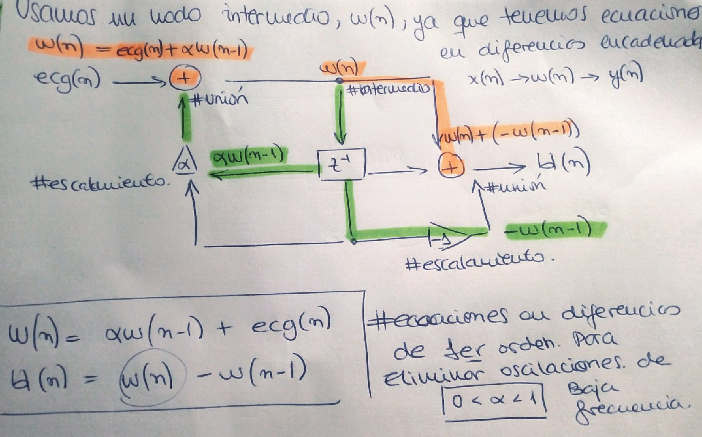

# 2. LABORATORIO

## 2.1.1 Promediado móvil

1. Calcula la respuesta impulsional de este sistema para N = 4 (20 términos).

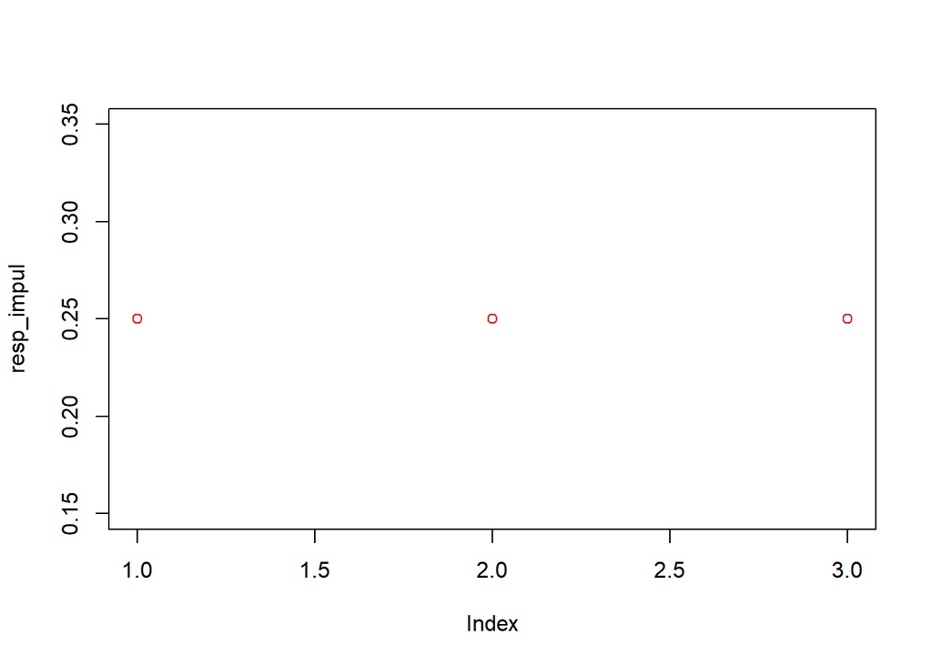

```r
x <- c(1,0,0,0,0,0,0,0,0,0,0,0,0,0,0,0,0,0,0,0)
n <- 4
resp_impul <- ecuacion_211(x,n)
plot(resp_impul,col='red')
```

2. Genera una señal de ruido Gaussiano de 1000 puntos (utiliza la instrucción randn, por ejemplo de la librería ramify ) y súmale un valor constante (componente de continua).

```r
library("ramify")
library("signal")
```

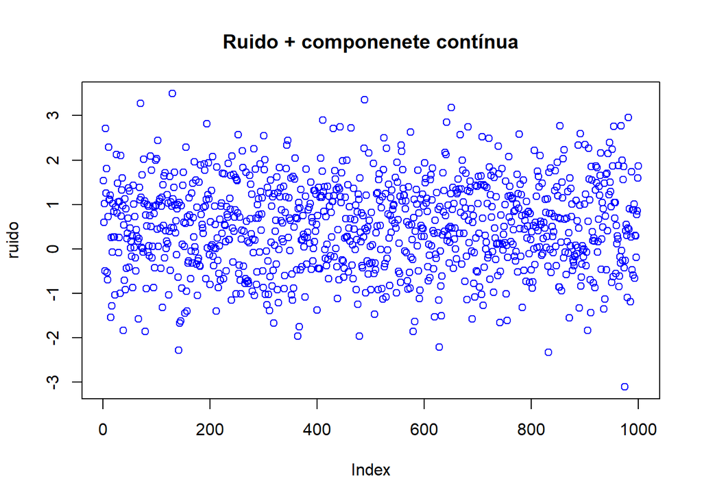

```r
# componente continua = 0.5
ruido <- randn(1000)+0.5
plot(ruido,col='blue',main='Ruido + componenete contínua')
```

3. Determina la salida del sistema convolucionando la respuesta impulsional y la entrada.

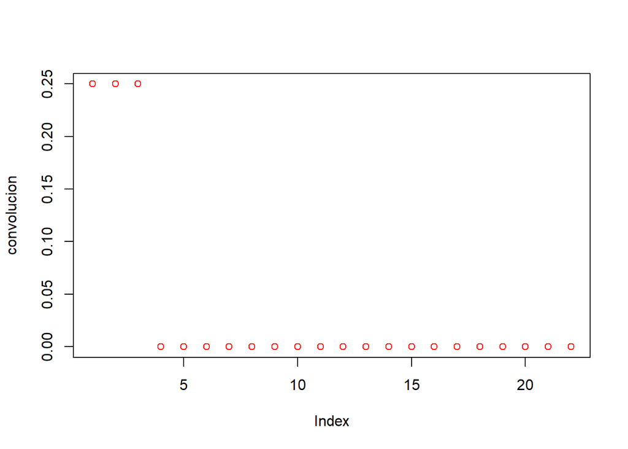

```r
convolucion <- conv(resp_impul, x) # convolución de resp_impul y la entrada x
plot(convolucion,col='red')
```

4. Representa la entrada y la salida en una misma gráfica con distinto color, ¿Qué diferencias observas entre ambas señales?

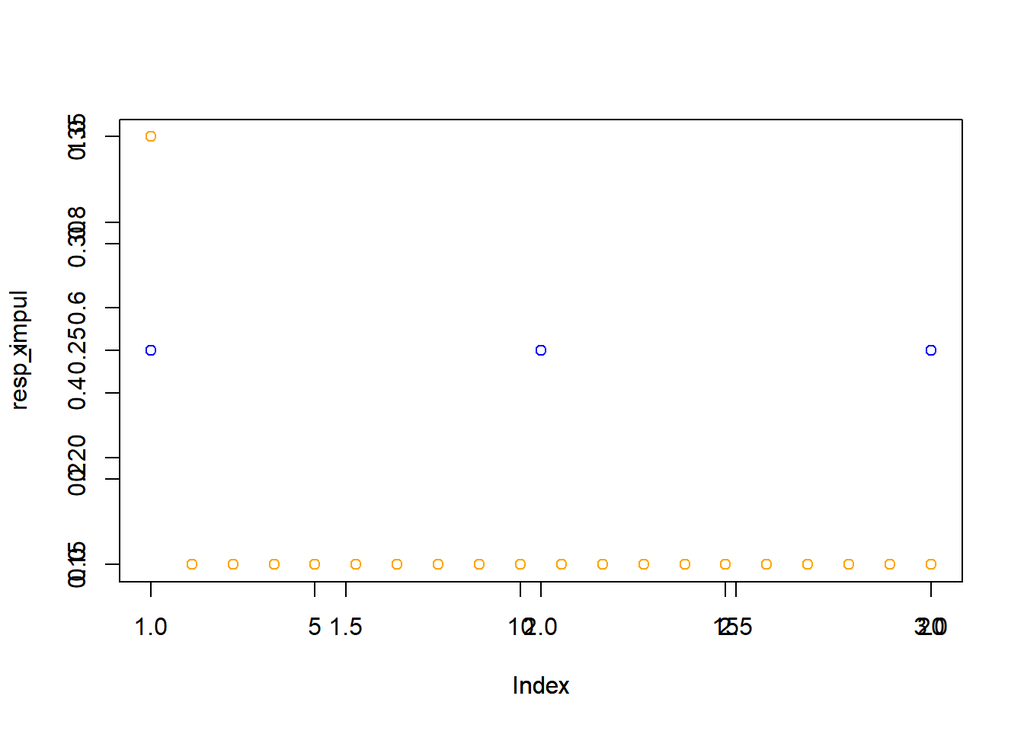

```r
plot(x,col='orange')
par(new=T)
plot(resp_impul,col='blue')
```

Los puntos azules representan el resultado de aplicar la media móvil para N=4. Los puntos naranjas son la entrada. La media móvil es el resultado de la media de los N anteriores. Esto equivale a sumar 1 + 0 + 0 + 0 y dividirlo entre 4. El resultado es 0.25.

Si aumentas N, ¿Qué diferencias observas entre la señal de entrada y la señal de salida a medida que aumenta N?

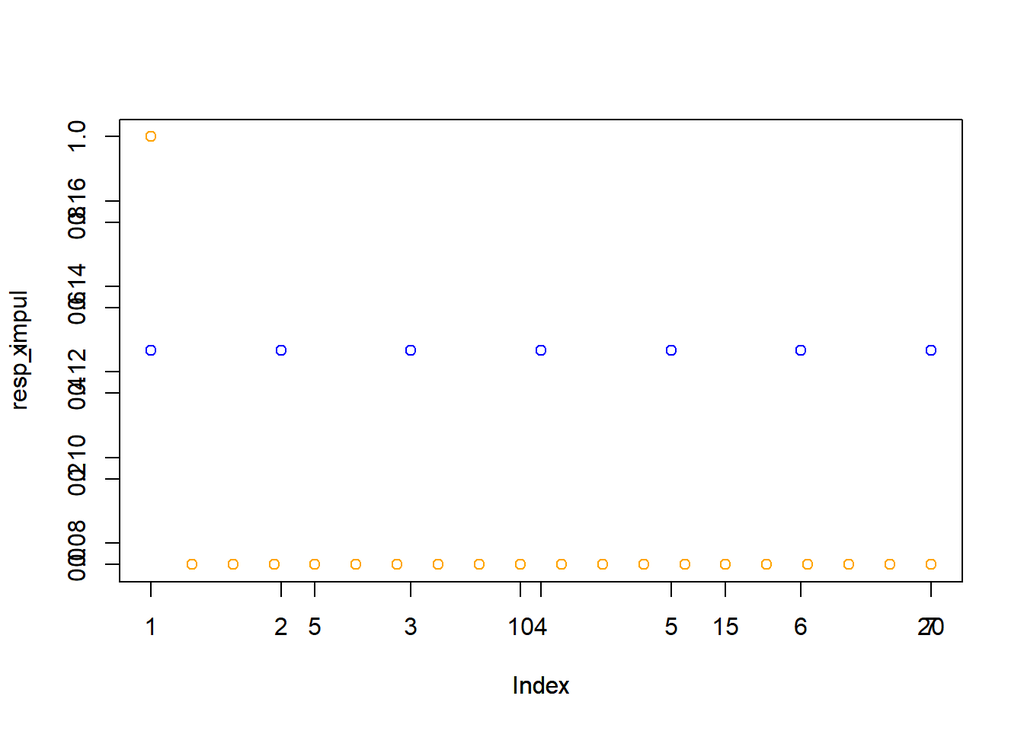

```r
# para n=8
resp_impul <- ecuacion_211(x,8)
plot(x,col='orange')
par(new=T)
plot(resp_impul,col='blue')
```

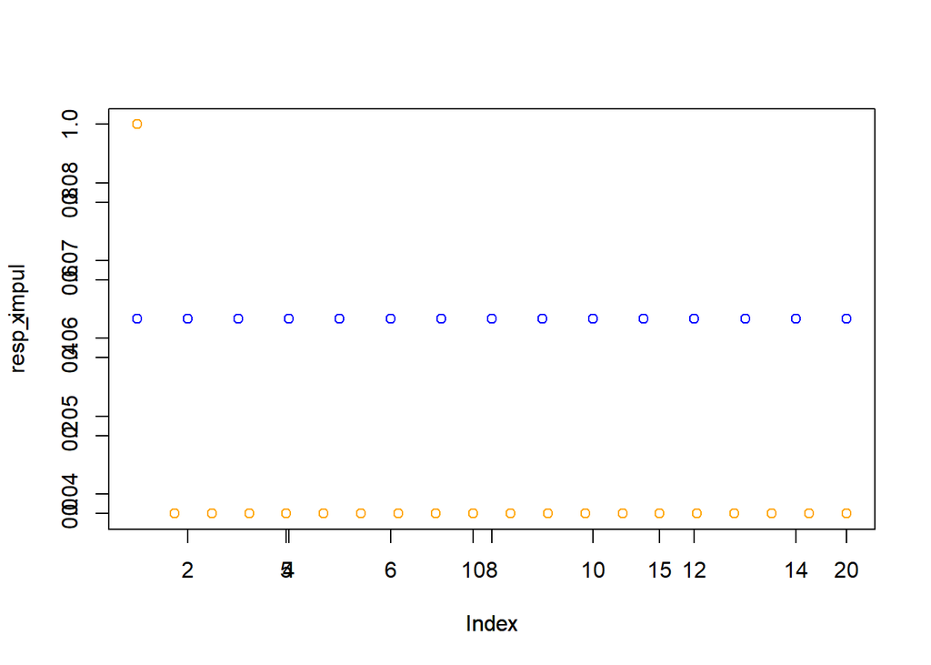

```r
# para n=16
resp_impul <- ecuacion_211(x,16)
plot(x,col='orange')
par(new=T)
plot(resp_impul,col='blue')
```

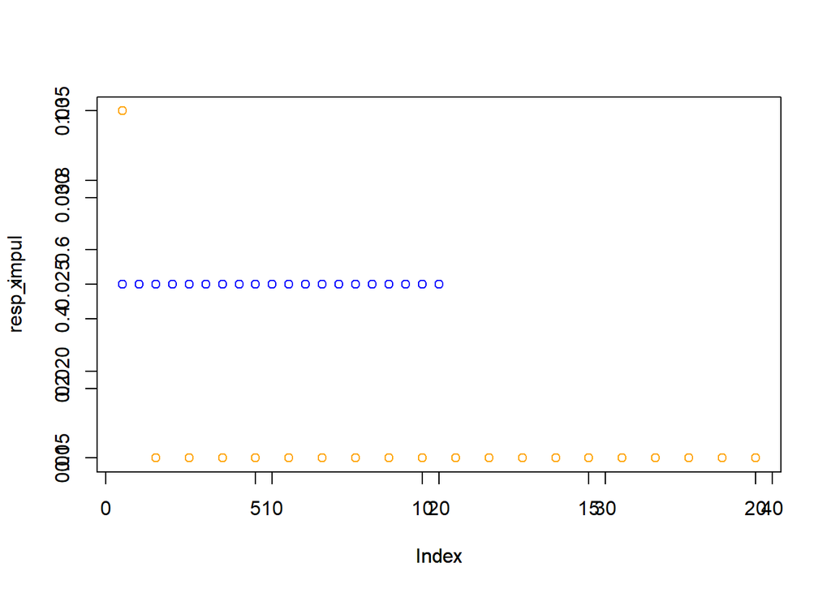

```r
# para n=40
resp_impul <- ecuacion_211(x,40)
plot(x,col='orange')
par(new=T)
plot(resp_impul,col='blue')
```

## 2.1.2 PROCESADO DE ELECTROCARDIOGRAMAS

Un sistema que elimina las oscilaciones de baja frecuencia en un electrocardiograma (oscilaciones de la línea base) puede ser implementado a partir diagrama de bloques de la Figura 1, donde es un parámetro variable (0 < < 1).

Escribe las ecuaciones en diferencias que te permiten calcular la salida del sistema a partir de la entrada.

$w(n) = \alpha w(n-1) + ecg(n)$ $bl(n) = w(n) - w(n-1)$

Calcula la salida a partir de las ecuaciones en diferencias1 utilizando como entrada la señal contenida en el fichero ecg.mat (Frecuencia de muestreo 1 kHz) y visualízalas. ¿Qué efecto tiene sobre la señal la modificación del parámetro?

```r
# cargamos fichero ecg.mat
# Abrimos carpeta 'data' donde se aloja el fichero
setwd("./data")
# importamos librerio
library(rmatio)
```

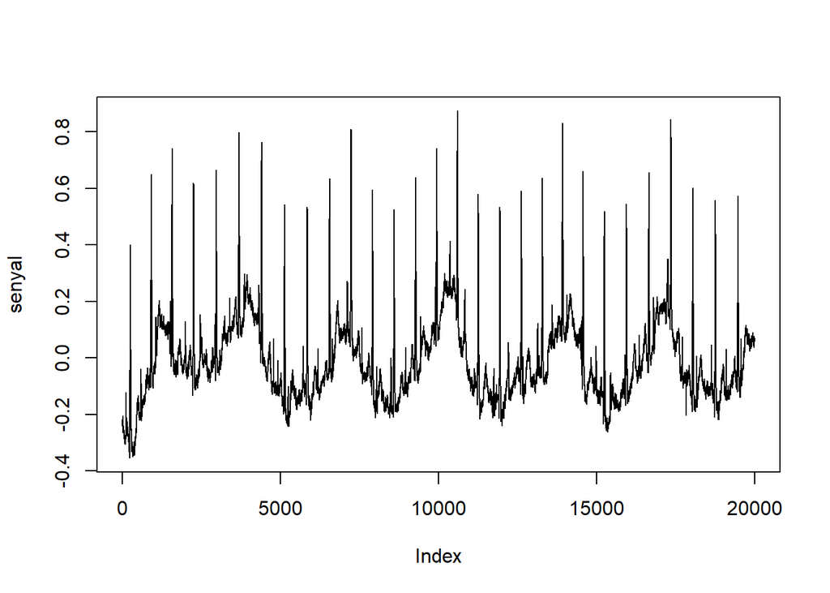

```r
# Leemos el fichero mat-lab
senyal <- read.mat('ecg.mat')
senyal <- senyal$ecg
plot(senyal,type='l') # visualizamos la señal ecg
```

Creamos la función electro_salida() que implementa las ecuaciones en diferencias anteriores. De esta forma, obtenemos la señal de salida, bl(n).

```r
electro_salida <- function(senyal,parametro){
  salida <- c() # vector vacío
  wn_anterior = 0
  for (i in 1:length(senyal)){
    wn = senyal[i] + parametro * wn_anterior
    bl = wn - wn_anterior # diferencia con el anterior
    wn_anterior = wn # el nuevo valor de wn
    salida <- append(salida,bl)}
  plot(senyal,ylim=c(-1,1),ylab='entrada-salida',type='l',col='blue',main='Comparación señales electrocardiograma')
  par(new=T)
  plot(salida,ylim=c(-1,1),ylab='entrada-salida',type='l',col='red')
}
```

¿Qué efecto tiene sobre la señal la modificación del parámetro?

```r
# prueba para alpha = 0
salida <- electro_salida(senyal,0)
```

[figure not shown]

```r
# prueba para alpha = 0.5
salida <- electro_salida(senyal,0.5)
```

[figure not shown]

```r
# prueba para alpha = 0.85
salida <- electro_salida(senyal,0.85)
```

[figure not shown]

```r
# prueba para alpha = 1
salida <- electro_salida(senyal,1)
```

[figure not shown]

Como podemos observar arriba, el efecto es que a medida que aumentamos el alfa se va pareciendo más a la señal original. Un alfa de 0.5 se mantiene alrrededor de una media de 0.